# Assignment_1

Shuo Mao 437681258

2024-07-23

# Task 1:

## Re-create the following sequences using R without the use of c() and explicit values. Hint: making use of the help files will sometimes help a lot.

(a):

`(i) [1] -4 4 -4 4 -3 3 -3 2 -2 1`

```r
{positive_numbers = rep(4:1, 4:1);#creating numbers
alternating_sequence = positive_numbers * rep(c(-1, 1),#using circle to re-assign their postie or negative sign to it
                                              length.out = length(positive_numbers))}
print(alternating_sequence)
```

```
##  [1] -4  4 -4  4 -3  3 -3  2 -2  1
```

`(ii) [1] 1 22 333 4444 55555 666666 7777777 88888888`

```r
# using function to create repeated number with no space, then adding space between each repeated numbers
formatted_sequence <- paste(sapply(1:8, function(x) paste(rep(x, x), collapse = ""))# will generate number such as: 1, 22, 333 ....
                            , collapse = " ") # combine those number and re-format it.

# Print the formatted sequence
cat(formatted_sequence)
```

```
## 1 22 333 4444 55555 666666 7777777 88888888
```

`(iii) [1] "z" "Y" "x" "W" "v" "U" "t" "S" "r" "Q" "p" "O" "n" "M" "l" "K" "j" "I" "h" "G" [21] "f" "E" "d" "C" "b" "A"`

```r
lowercase <- rev(letters)  # "z" to "a"
uppercase <- rev(LETTERS)  # "Z" to "A"

#combine uppercase and lowercase alternatively
combined <- c(rbind(lowercase[seq(1, 26, 2)], uppercase[seq(2, 26, 2)]))

# Print the combined sequence
print(combined)
```

```
##  [1] "z" "Y" "x" "W" "v" "U" "t" "S" "r" "Q" "p" "O" "n" "M" "l" "K" "j" "I" "h"
## [20] "G" "f" "E" "d" "C" "b" "A"
```

`(iv) [1] "1^1=1" "2^2=4" "3^3=27" "4^4=256" "5^5=3125" [6] "6^6=46656" "7^7=823543" "8^8=16777216"`

```r
# Calculate the power results
{exponents <- 1:8;results <- paste(exponents, "^", exponents, "=", exponents^exponents)}
print(results)
```

```
## [1] "1 ^ 1 = 1"        "2 ^ 2 = 4"        "3 ^ 3 = 27"       "4 ^ 4 = 256"
## [5] "5 ^ 5 = 3125"     "6 ^ 6 = 46656"    "7 ^ 7 = 823543"   "8 ^ 8 = 16777216"
```

`(v) [1] "jan1" "feb2" "mar3" "apr4" "may5" "jun6" "jul7" "aug8" "sep9" "oct10" [11] "nov11" "dec12"`

```r
# Create the vector of month abbreviations and corresponding numbers, then Combine the month abbreviations with the numbers
{months <- tolower(month.abb);numbers <- 1:12;result <- paste(months, numbers, sep = "")}
# Print the result
print(result)
```

```
##  [1] "jan1"  "feb2"  "mar3"  "apr4"  "may5"  "jun6"  "jul7"  "aug8"  "sep9"
## [10] "oct10" "nov11" "dec12"
```

(b): find and write down six different ways to assign a variable x the value 8

1: using ‘=’

```r
x = 8
print(x)
```

```
## [1] 8
```

2: using ‘->’

```r
(8 -> x)
```

```
## [1] 8
```

3: using ‘<-’

```r
(x <- 8)
```

```
## [1] 8
```

4: using assign function

```r
(assign("x", 8))
```

```
## [1] 8
```

```r
(x <<- 8)
```

```
## [1] 8
```

6: using eval function

```r
(eval(x <- 8))
```

```
## [1] 8
```

```r
## in addition can also using c() function to assign value's
(x <- c(9,8,1,4)[2])
```

```
## [1] 8
```

## (c) We know that ex = ∑∞ i=0 xi/i!. Approximate this by A(k; x) = ∑k i=0 xi/i! for finite k. Find the value k such that A(k; 1) does not differ by exp(1) on your machine.

```r
# Compute Euler's number
e <- exp(1)

# Initialize variables
k <- 0
approximation <- 0
tolerance <- .Machine$double.eps *2 # Machine precision (default tolerance)

# Loop to find the smallest k
repeat {
  # Update the approximation of A(k; 1)
  approximation <- approximation + 1 / factorial(k)

  # Check if the approximation is within the tolerance
  if (abs(approximation - e) <= tolerance) {
    break
  }

  # Increment k
  k <- k + 1
}

# Output the result
cat(sprintf("The smallest k such that A(k; 1) approximates exp(1) within machine precision is: %d\n", k))
```

```
## The smallest k such that A(k; 1) approximates exp(1) within machine precision is: 17
```

first I compute the e, then initialized the variables, using repeat loop to calculate the smallest k, but initial tolerance was to small that the calculation takes forever then so I use a relatively small number to replace original tolerance to make the calculation faster.

# Task 2:Consider the data frame xs.nz in VGAMdata. Based on this cross-sectional study, use R expressions (not your eyes or my eyes) to find the values below (and show the values only, nothing else). Don’t use any explicit loop or anything equivalent. Ignore (delete) any cases with NAs in the relevant variables. Your code should be elegant and readable, etc

### (a):The proportion of females who have had an acne problem

```r
### @Desc: query index that sex columns equals "F" and acne columns equals "1"
mean(xs.nz[!is.na(xs.nz[, "sex"]) & !is.na(xs.nz[, "acne"]) & xs.nz[, "sex"] == "F", "acne"] == 1)
```

```
## [1] 0.08202859
```

This output indicates the proportion of females who had an acne problem which from the result it is approximately 0.082

### (b):What is the age of the oldest Maori who has a cat and a dog?

```r
### @Desc: select column name that satisfy requirement ethnicity equals Maori, dog equals 1 and cat equals 1
(age <- max(xs.nz[(xs.nz[, "ethnicity"] == "Maori" & xs.nz[, "dog"] == 1 & xs.nz[, "cat"] == 1), "age" ], na.rm = T))
```

```
## [1] 64
```

```r
### @Desc: Selecting all data column's that have zero miss value
non_miss_value <-xs.nz[!is.na(xs.nz[,"smokenow"]) & !is.na(xs.nz[,"drinkfreqweek"]),]

### @Desc: Query the "drinkfreqweek" column for those who also satisfy the condition "smokenow" equals 1
(smoke <- nrow(non_miss_value[non_miss_value[, "smokenow"] == 1 & non_miss_value[, "drinkfreqweek"] >= 1, ])/nrow(non_miss_value[non_miss_value[, "smokenow"] == 1, ]))
```

```
## [1] 0.7103336
```

```r
### @Desc: Query the "drinkfreqweek" column for those who also satisfy the condition "smokenow" equals 0

(non_smoke <- nrow(non_miss_value[non_miss_value[, "smokenow"] == 0 & non_miss_value[, "drinkfreqweek"] >= 1, ])/nrow(non_miss_value[non_miss_value[, "smokenow"] == 0, ]))
```

```
## [1] 0.6503541
```

# Task 3: Write some very short R code (or R functions) to compute the following series or products. You must create each term to do the addition/multiplication. If you write a function, it should have an argument n which can be assumed to have good input. Obtain the answer for n = 64 for cases (a)–(d)

a:

```r
sum_series <- function(n) {
  ### @param: Denominator (n-1) * n
  ### @Return: result of math function sum(n) 1/(n-1)*n

  # condition that throw a warning to reminder user of range of vaild value
  if (length(n) != 1 || n < 0 || !is.finite(n) || n != floor(n)|| n==0)
         warning("invalid inputs\n") # will throw an error when process decimal numbers, empty inputs, negative number and zeros

  if(n==0) {
    return(0) # if n is 0
  }

  # Actual math function
  sum(1 / (1:(n-1) * 2:n))
}

(result_a <- sum_series(64))
```

```
## [1] 0.984375
```

b:

```r
product_series <- function(n){
   ### @param: Denominator n and power (n + 1)
   ### @return result of math function (1+ (-1)^n / n-1) * (1 + (-1)^(n+1)/n)
   if (length(n) != 1 || n < 0 || !is.finite(n) || n==0)
         warning("invalid inputs\n") # will throw an error when process  empty inputs, negative number and zeros


  if(n ==0) return(1)
  product <- 1

  for (i in 1:n) {
    product <- product * (1 + ((-1)^(i+1)) / i)
  }

  product
}


result_b <- product_series(64)
print(result_b,digits=16)# need to spcify the digits length, otherwise it automatically converted into 1
```

```
## [1] 0.9999999999999982
```

c:

```r
product_series_c = function(n){
  ### @param: Denominator n
  ### @return: output of math equation (1 + 1/(n * n+2))
  if (!is.numeric(n) ||  !is.finite(n) || n==0|| n <1)
         warning("invalid inputs\n") # will throw an error when process  empty inputs,  and zeros
  if(n == 0) return(1)
  product = 1
  for (i in 1:n) {
    product = product * (1 + 1 / (i* (i+2) ) ) # (1 + 1 / n * n) * (1 + 1 / n * n+1)

  }
  product
}



(result_c <- product_series_c(64))
```

```
## [1] 1.969697
```

d:

```r
sum_inf <- function(n, eps = 1e-8) {
  ### @param: Denominator n:  k* (k+n-1) *  (k+n)
  ### @return: result of math function: sum 1/ k* (k+n-1) *  (k+n)
  if (length(n)  <1 ||  !is.finite(n) || n==0 || n != floor(n))
         warning("invalid inputs\n") # will throw an error when process  empty inputs,  and zeros

  if(n!=floor(n)|| n == 0) return(NaN) # neither case will make term smaller than eps; hence will never stop
  if(n<0)return(0) # negative one of k will match with n hence, entire denominator will became to zero
  sum_val <- 0
  k <- 1
  term <- 1 # temp holder
  while (term > eps) {
    term <- 1 / prod(k:(k+n)) # 1/ k* (k+n-1) *  (k+n)
    sum_val <- sum_val + term # sum function
    k <- k + 1 # accumulating from 1 to inf

  }
  sum_val
}



(result_d <- sum_inf(64))
```

```
## [1] 1.212466e-91
```

e:

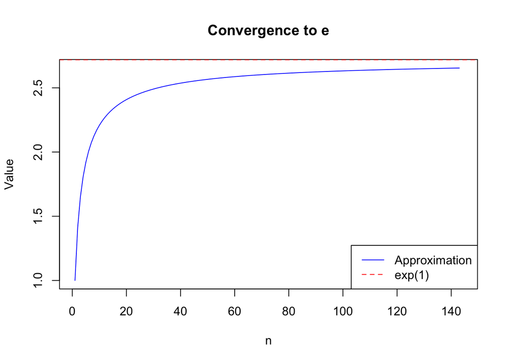

```
## Max iteration at  143
```

```
##       n    value diff_from_e
## 1     1 1.000000  1.71828183
## 2     2 1.414214  1.30406827
## 3     3 1.650964  1.06731820
## 4     4 1.807204  0.91107782
## 5     5 1.919260  0.79902208
## 6     6 2.004145  0.71413670
## 7     7 2.070997  0.64728520
## 8     8 2.125201  0.59308127
## 9     9 2.170157  0.54812529
## 10   10 2.208125  0.51015662
## 11   11 2.240673  0.47760858
## 12   12 2.268923  0.44935844
## 13   13 2.293703  0.42457887
## 14   14 2.315636  0.40264581
```

[output cut: 130 more lines]

```r
compute_limit <- function(max_n = 100,threshold = 1e8, tol = 1e-8) {
  ### @param: time of iteration
  ### @return data frame that contains iteration times, value of math function and difference from exp(1)

  if (length(max_n)  <1 || max_n < 0 ||  !is.finite(max_n) || max_n==0 || max_n != floor(max_n))
         stop("invalid inputs\n") # will throw an error when process  empty inputs,  and zeros

  results <- data.frame(n = integer(), value = numeric(), diff_from_e = numeric())# create data frame contain n, value, and difference
  e <- exp(1)

  for (n in 1:max_n) {
    value <- (n^n / factorial(n))^(1/n) # calculate function
    diff_from_e <- abs(value - e)# calculate difference, the smaller the number closer to e
    results <- rbind(results, data.frame(n = n, value = value, diff_from_e = diff_from_e))# append result to data frame for better readability
    if (diff_from_e > threshold || diff_from_e<tol) { # stop when the diff_from_e is reach the floating point and turn into inf
      break
    }
  }
  # plot the performance
  plot(results$n, results$value, type = "l", col = "blue",
       xlab = "n", ylab = "Value", main = "Convergence to e")
  abline(h = e, col = "red", lty = 2)
  legend("bottomright", legend = c("Approximation", "exp(1)"),
         col = c("blue", "red"), lty = c(1, 2))

  cat("Max iteration at ", n -1,"\n")# indicate the actual stop rounds
  results
}


(result <- compute_limit(1000))
```

this function is specifically to calculate the maximum number of iteration time that its result approach to exp(1), stop if the difference is smaller than the tolerance point or calculation are reach to floating point.

# 4： Solve the following short problems using R

1. random variable has a discrete Lindley distribution if its probability mass function is f (x; θ) = (1 − e−θ)2 (1 + x) e−θx, x = 0, 1, 2, . . . , (1) where θ > 0. Write a function ddislind(x, shape, log.arg = FALSE) for (1). That is, it should work for vectors x and shape, and logical log.arg. If the latter is TRUE then log f is returned.

```r
ddislind <- function(x, shape, log.arg = FALSE) {
  ### @param:
        # x:A vector of integer values at which the PMF needs to be evaluated.
        # shape: A vector of the same length as x containing the parameter θ.
        # log.arg: A logical argument that determines whether to return the logarithm of the PMF (log(f)).
  ### @return: if log.arg == true, should return PMF value

  # Check if x and shape are vectors of the same length
  if (length(x) != length(shape)) {
    warning("x and shape should be vectors of the same length")
  }

  # Calculate the PMF for the discrete Lindley distribution
  pmf <- (1 - exp(-shape))^2 * (1 + x) * exp(-shape * x)

  # If log.arg is TRUE, return the logarithm of the PMF
  if (log.arg) {
    return(log(pmf))
  } else {
    return(pmf)
  }
}

# test case
#ddislind((0:10), c(5,10))

x <- 0:10
shape <- rep(2, length(x))  # Example with theta = 2 for all x values
ddislind(x, shape)          # PMF values
```

```
##  [1] 7.476451e-01 2.023655e-01 4.108079e-02 7.412907e-03 1.254035e-03
##  [6] 2.036582e-04 3.215583e-05 4.973507e-06 7.572273e-07 1.138662e-07
## [11] 1.695112e-08
```

```r
ddislind(x, shape, log.arg = TRUE)  # Log PMF values
```

```
##  [1]  -0.2908269  -1.5976797  -3.1922146  -4.9045326  -6.6813890  -8.4990674
##  [7] -10.3449168 -12.2113854 -14.0936023 -15.9882418 -17.8929316
```

Calculate the probability mass function (PMF) of the discrete Lindley distribution for a vector of integer values and a corresponding shape parameter vector, with an option to return the logarithm of the PMF. Key inputs: - x:A vector of integer values at which the PMF needs to be evaluated. - shape: A vector of the same length as x containing the parameter θ. - log.arg: A logical argument that determines whether to return the logarithm of the PMF (log(f)).

b)Use your function to give evidence that ∑∞ x=0 f (x; θ) = 1 is satisfied—a property that should hold for any valid PMF

```r
verify_pmf_sum <- function(theta, tol = 1e-8, max_x = 1e6) {
  ### @param: element value of theta
  ### @return: as expect sum_pmf should return 1

   # Create a sequence of x values from 0 to max_x
  x <- 0:max_x
  # Generate a vector of shape parameters, all set to the value of theta
  shape <- rep(theta, length(x))
  # Calculate the probability mass function (PMF) values for each x
  pmf_values <- ddislind(x, shape)
  sum_pmf <- sum(pmf_values)
  sum_pmf
}


(sum_pmf <- verify_pmf_sum(theta = 12))
```

```
## [1] 1
```

As predicted, the output result of the probability mass function (PMF) should approach one as x increases, and theta has no influence on this function.

# 5:Use R to solve the following problems

### a)If 2 ‘large’ earthquakes occur on average each year at a particular city, what is the probability at least 8 occur during a 5 year period?

```r
# λ for the 5-year period = 2 time earthquakes * 5 years
# x for probability of having 7 or fewer earthquakes
(prob_earthquakes <- 1 - ppois(7, lambda = 2 * 5))
```

```
## [1] 0.7797794
```

ppois = Poisson Distribution, is a specific function for probability

### b) new organization is proposed, called ASNEM, whose sole criterion is that members must have an intelligence quotient (IQ) in the bottom 3% of the general population. Suppose IQs are normally distributed with mean 100 and standard deviation 15. What is the cutoff point for the society?

```r
# means to find  the 3rd percentile of the normal distribution with mean 100 and standard deviation 15.
(cutoff <- qnorm(0.03,  100, 15))
```

```
## [1] 71.7881
```

qnorm = basic normal distribution function, whereas x = 0.03, mean = 100, and deviation = 15

### c)Somebody called Fred is willing to make as many attempts at getting his drivers licence as needed until he gets it. He estimates the probability of success of each test is 0.2. What is the probability of getting his drivers licence within 5 attempts?

```r
#using geometric distribution for modeling the number of trials needed to get the first success, using 4 is because pgeom start form 0
(prob_license <- pgeom(4, prob = 0.2))
```

```
## [1] 0.67232
```

The geometric distribution models the number of trials needed to achieve the first success, where each trial has a fixed probability of success. in this case, with a success probability of 0.2, the probability of achieving the first success within 5th trial is described by this distribution.

# 6

a)Write R expressions (or, better yet, R functions) that evaluate the variance according to the two formulas above. Given the set of data `> x <- c(1.5, 17, 2.5, 12, 21.3)` compute the variances of x, x+10, x+10^2, x+10^3, . . . , x+10^10. When do the results start to differ noticeably? Comment.

```r
standard_variance <- function(x) {
  ### @param: sample population x
  ### @return: standard variance of x

  n <- length(x) -1  # degree of freedom
  mean_x <- mean(x) # mean of x
  sum((x - mean_x)^2) / (n )
}

desk_calculator_variance <- function(x) {
  ### @param: sample population x
  ### @return:  variance of x
  n <- length(x) # degree of freedom (-1 when use it)
  result <- sum(x^2) / (n - 1) - sum(x)^2 / (n * (n - 1))
}

x <- c(1.5, 17, 2.5, 12, 21.3)
standard_variance(x)
```

```
## [1] 76.373
```

```r
desk_calculator_variance(x)

# Compute variances for x + 10^k
results <- sapply(1:10, function(k) {
  x_transformed <- x + 10^k
  var_standard_transformed <- standard_variance(x_transformed)
  var_desk_transformed <- desk_calculator_variance(x_transformed)
  return(c(var_standard_transformed, var_desk_transformed))
})

(results)
```

```
##        [,1]   [,2]   [,3]   [,4]   [,5]     [,6]     [,7]   [,8]     [,9]
## [1,] 76.373 76.373 76.373 76.373 76.373 76.37300 76.37300 76.373   76.373
## [2,] 76.373 76.373 76.373 76.373 76.373 76.37329 76.39062 76.000 -256.000
##           [,10]
## [1,]     76.373
## [2,] -16384.000
```

2. Use var() on the same vectors of data. Comment on the results

```r
# modify result function
results <- sapply(1:10, function(k) {
  x_transformed <- x + 10^k
  var_standard_transformed <- standard_variance(x_transformed)
  var_desk_transformed <- desk_calculator_variance(x_transformed)
  var_2 <- var(x_transformed)
  return(c(var_standard_transformed, var_desk_transformed, var_2))
})

(results)
```

```
##        [,1]   [,2]   [,3]   [,4]   [,5]     [,6]     [,7]   [,8]     [,9]
## [1,] 76.373 76.373 76.373 76.373 76.373 76.37300 76.37300 76.373   76.373
## [2,] 76.373 76.373 76.373 76.373 76.373 76.37329 76.39062 76.000 -256.000
## [3,] 76.373 76.373 76.373 76.373 76.373 76.37300 76.37300 76.373   76.373
##           [,10]
## [1,]     76.373
## [2,] -16384.000
## [3,]     76.373
```

Observed from the output above, it is demonstrated that both standard_variance and var() are able to generate correct results even after the 10th iteration. In contrast, desk_calculator_variance starts to lose accuracy after the 5th iteration and completely loses its ability to handle the dataset after the 9th iteration.

```r
results <- sapply(1:20, function(k) {
  x_transformed <- x + 10^k
  var_standard_transformed <- standard_variance(x_transformed)
  var_desk_transformed <- desk_calculator_variance(x_transformed)
  var_2 <- var(x_transformed)
  return(c(var_standard_transformed, var_desk_transformed, var_2))
})

(results)
```

```
##        [,1]   [,2]   [,3]   [,4]   [,5]     [,6]     [,7]   [,8]     [,9]
## [1,] 76.373 76.373 76.373 76.373 76.373 76.37300 76.37300 76.373   76.373
## [2,] 76.373 76.373 76.373 76.373 76.373 76.37329 76.39062 76.000 -256.000
## [3,] 76.373 76.373 76.373 76.373 76.373 76.37300 76.37300 76.373   76.373
##           [,10]        [,11]    [,12]        [,13]         [,14]    [,15]
## [1,]     76.373 7.637302e+01 76.37325 7.637708e+01  7.635669e+01 76.11328
## [2,] -16384.000 2.097152e+06  0.00000 1.717987e+10 -2.199023e+12  0.00000
## [3,]     76.373 7.637302e+01 76.37325 7.637708e+01  7.635669e+01 76.11328
##             [,16] [,17]       [,18]         [,19] [,20]
## [1,]  7.80000e+01   128 0.00000e+00  0.000000e+00     0
## [2,] -1.80144e+16     0 1.47574e+20 -1.888947e+22     0
## [3,]  7.80000e+01   128 0.00000e+00  0.000000e+00     0
```

In addition, if we extend our iterations further, we can observe that both var() and standard_variance begin to lose accuracy after the 11th iteration and completely lose their ability to produce correct outputs by the 17th iteration.